# Traffic_Sign_Classifier

## Project: Build a Traffic Sign Recognition Program

### Overview

In this project, I used convolutional neural networks to classify traffic signs from [German Traffic Sign Dataset](http://benchmark.ini.rub.de/?section=gtsrb&subsection=dataset). The code about this project is in the file `Traffic_Sign_Classifier.ipynb`

### The Process of this Project

The steps of this project are the following:

- 1. Load the data set
- 1. Explore, summarize and visualize the data set
- 1. Design, train and test a model architecture
- 1. Use the model to make predictions on new images
- 1. Analyze the softmax probabilities of the new images

### Dependencies

This lab requires:

- [CarND Term1 Starter Kit](https://github.com/udacity/CarND-Term1-Starter-Kit)

The lab environment can be created with CarND Term1 Starter Kit. Click [here](https://github.com/udacity/CarND-Term1-Starter-Kit/blob/master/README.md) for the details.

## Write Up

This write up is to summarize the process and technologies about this project in detail.

### 1. Load the data set

**code:** Code Part 1

- The pickled data is stored in the folder named `Data`.
  - `'features'` is a 4D array containing raw pixel data of the traffic sign images, (num examples, width, height, channels).
  - `'labels'` is a 1D array containing the label/class id of the traffic sign. The file `signnames.csv` contains id -> name mappings for each id.
  - `'sizes'` is a list containing tuples, (width, height) representing the original width and height the image.
  - `'coords'` is a list containing tuples, (x1, y1, x2, y2) representing coordinates of a bounding box around the sign in the image.

```python
########## Code Part 1: Load pickled data

import csv
import pickle
import os
import numpy as np

## Get the path of folder
# os.getcwd() is to get path of current workspace.
path_folder = os.getcwd()

training_file = path_folder+'/Data/train.p'
validation_file= path_folder+'/Data/valid.p'
testing_file = path_folder+'/Data/test.p'

with open(training_file, mode='rb') as f:
    train = pickle.load(f)
with open(validation_file, mode='rb') as f:
    valid = pickle.load(f)
with open(testing_file, mode='rb') as f:
    test = pickle.load(f)

## get features and labels of data.
X_train, y_train = train['features'], train['labels']
X_valid, y_valid = valid['features'], valid['labels']
X_test, y_test = test['features'], test['labels']

X_train0, y_train0  = train['features'], train['labels']


#Create a dict that maps labels to actual signnames
sign_name = {}
with open('signnames.csv') as csvfile:
    reader = csv.reader(csvfile)
    next(reader)
    for row in reader:
        sign_name[int(row[0])] = row[1]
```

### Step 2: Explore, summarize and visualize the data set

#### A Basic Summary of the Data Set

**Code:** Code Part 2

```python
############ Code Part 2: A Basic Summary of the Data Set

# TODO: Number of training examples
n_train = len(X_train)

# TODO: Number of validation examples
n_valid = len(X_valid)

# TODO: Number of testing examples.
n_test = len(X_test)

# TODO: Shape of traffic sign image
image_shape = X_train.shape[1:]

# TODO: How many unique classes/labels there are in the dataset.
n_classes = max(y_train) - min(y_train) + 1

print("Number of training examples =", n_train)
print("Number of validation examples =", n_valid)
print("Number of testing examples =", n_test)
print("Image data shape =", image_shape)
print("Number of classes =", n_classes)
```

```
Number of training examples = 34799
Number of validation examples = 4410
Number of testing examples = 12630
Image data shape = (32, 32, 3)
Number of classes = 43
```

#### Include an exploratory visualization of the dataset

**Code**: `Code Part 3`, `Code Part 4`

- Plotting traffic sign images,
- Plotting the count of each sign in the training, validation and test set.

**Observation:**

```
(0.0, 1.0, 0.0, 1.0)
```

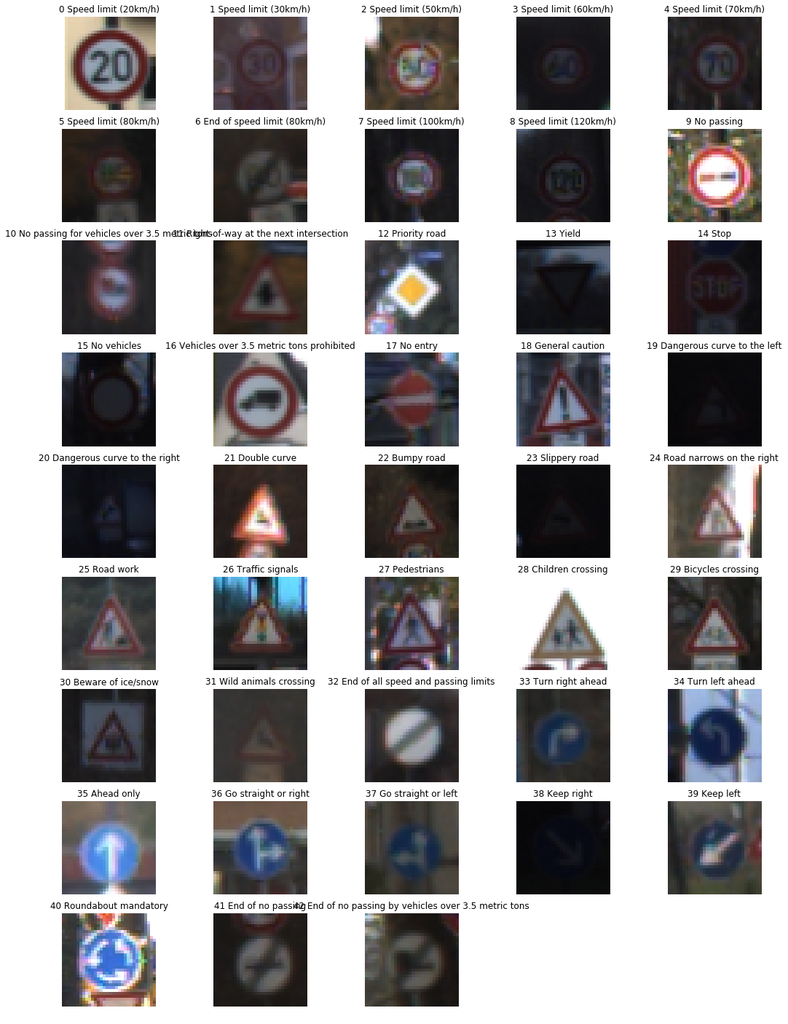

```python
############## Code Part 3: Plotting traffic sign images

import matplotlib.pyplot as plt
import random

##### plotting traffic sign images

# get the classes lable index in y_train
lable_index = []

for i in range(0,n_classes):
    a = np.argwhere(y_train==i)
    lable_index.append(a[0][0])


# plot traffic sign images
fig, axes = plt.subplots(9, 5, squeeze = True, figsize=(18, 25))
axes = axes.ravel()     # axes is a matrix, now make it a vector
for i in range(n_classes):
    axes[i].imshow(X_train[lable_index[i]])
    axes[i].axis('off')
    name = y_train[lable_index[i]]
    axes[i].set_title(str(i)+' '+sign_name[name])

axes[43].axis('off')
axes[44].axis('off')
```

```
Text(0.5,1,'Histogram')
```

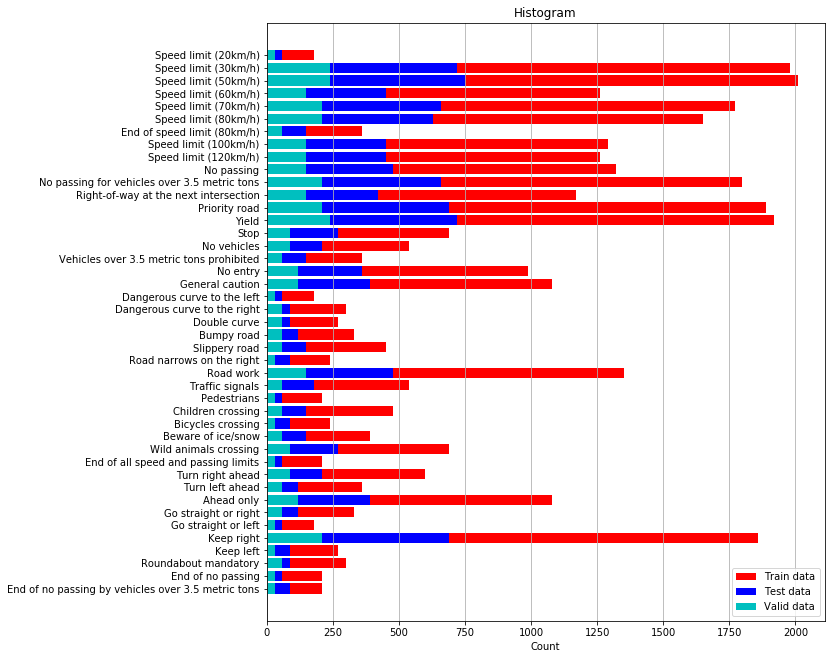

```python
############## Code Part 4: plotting the count of each sign

labels = sign_name.values()

classIds, classCounts = np.unique(y_train, return_counts=True)
classIds, fstIdxToClasses = np.unique(y_train, return_index=True)
n_classes = len(classIds)

ValidClassIds, ValidClassCounts = np.unique(y_valid, return_counts=True)
ValidClassIds, fstIdxToValidClasses = np.unique(y_valid, return_index=True)
n_validClasses = len(ValidClassIds)

testClassIds, testClassCounts = np.unique(y_test, return_counts=True)
testClassIds, fstIdxToTestClasses = np.unique(y_test, return_index=True)
n_testClasses = len(testClassIds)

fig, ax = plt.subplots()
fig.set_size_inches(10,11)
plt.gca().invert_yaxis()
plt.gca().xaxis.grid()

plt.barh(classIds, classCounts, label='Train data', color= 'r' )
plt.barh(classIds, testClassCounts, label='Test data', color= 'b')
plt.barh(classIds, ValidClassCounts, label='Valid data', color = 'c')
ax.set_yticks(classIds)
ax.set_yticklabels(labels)
plt.xlabel('Count')
plt.legend()
plt.title("Histogram")
```

###### Step 3: Design and Test a Model Architecture

- Preprocessing images
- Model Architecture
- Model Training
- Solution Approach

#### Preprocessing images

**Code**: `Code Part 5`

- The color-to-grayscale algorithm is Intensity, which calculates the mean of the RGB channels.
- Normalized the grayscale image by `normalized = (gray - 128) / 128`.

```python
########## Code Part 5: Preprocess the data

import cv2
from sklearn.utils import shuffle
import tensorflow as tf

### converting to grayscale and normalized the grayscaled images.
def pre_process(image):

    # Convert images to grayscale
    gray = np.sum(image/3, axis = 3, keepdims=True)

    # Normalize grayscaled images
    normalized = (gray - 128) / 128

    return normalized

X_train = pre_process(X_train)
X_valid = pre_process(X_valid)
X_test = pre_process(X_test)
```

#### Model Architecture

**Code**: `Code Part 6`

The Architecture consist of 8 layers:

**Why this Architecture:** My work is based on LeNet, and I add three dropout to avoid overfitting. I choose LeNet is because it is a reliable tamplet.

```python
############## Code Part 6: Define Model Architecture.

from tensorflow.contrib.layers import flatten

def LeNet(x):

    # initialize the weights
    # Arguments used for tf.truncated_normal, randomly defines variables for the weights and biases for each layer
    mu = 0
    sigma = 0.1

    ##### SOLUTION:
    ### Layer 1: Convolutional (C1). Input = 32x32x1. Output = 28x28x6.
    # initialize weights
    # shape=(5, 5, 1, 6) means the filter size is (H=5, W=5) with input_depth=1, output_depth=6
    conv1_W = tf.Variable(tf.truncated_normal(shape=(5, 5, 1, 6), mean = mu, stddev = sigma))
    # initialize bias, length = output_depth = 6
    conv1_b = tf.Variable(tf.zeros(6))
    # convolve the filter over image
    conv1   = tf.nn.conv2d(x, conv1_W, strides=[1, 1, 1, 1], padding='VALID') + conv1_b
    # output_height = (input_height - filter_height + 1)/stride_vertical = (32-5+1)/1 = 28
    # Activation.
    conv1 = tf.nn.relu(conv1)

    # Layer 2: Pooling (S2). Input = 28x28x6. Output = 14x14x6.
    # pool the C1 layer with 2X2 kernel with 2X2 Stride
    conv1 = tf.nn.max_pool(conv1, ksize=[1, 2, 2, 1], strides=[1, 2, 2, 1], padding='VALID')

    # Layer 3: Convolutional (C3). Input = 14x14x6; Output = 10x10x16.
    # shape=(5, 5, 6, 16) means the filter size is (H=5, W=5) with input_depth=6, output_depth=16
    conv2_W = tf.Variable(tf.truncated_normal(shape=(5, 5, 6, 16), mean = mu, stddev = sigma))
    conv2_b = tf.Variable(tf.zeros(16))
    conv2   = tf.nn.conv2d(conv1, conv2_W, strides=[1, 1, 1, 1], padding='VALID') + conv2_b
    # Activation: Relu.
    conv2 = tf.nn.relu(conv2)

    # Layer 4: max pooling (S4): Input = 10x10x16. Output = 5x5x16.
    # pool the C3 layer with 2X2 kernel with 2X2 Stride
    conv2 = tf.nn.max_pool(conv2, ksize=[1, 2, 2, 1], strides=[1, 2, 2, 1], padding='VALID')

    # Layer 5: Flatten layer (F5). Input = 5x5x16. Output = 400.
    # flat layer S4 to a vector
    fc0   = flatten(conv2)
    fc0  = tf.nn.dropout(fc0 , keep_prob)

    # Layer 6: Fully Connected (F6). Input = 400. Output = 120.
    fc1_W = tf.Variable(tf.truncated_normal(shape=(400, 120), mean = mu, stddev = sigma))
    fc1_b = tf.Variable(tf.zeros(120))
    fc1   = tf.matmul(fc0, fc1_W) + fc1_b
    # Activation.
    fc1    = tf.nn.relu(fc1)
    fc1  = tf.nn.dropout(fc1 , keep_prob)

    # Layer 7: Fully Connected (F7). Input = 120. Output = 84.
    fc2_W  = tf.Variable(tf.truncated_normal(shape=(120, 84), mean = mu, stddev = sigma))
    fc2_b  = tf.Variable(tf.zeros(84))
    fc2    = tf.matmul(fc1, fc2_W) + fc2_b
    # Activation.
    fc2    = tf.nn.relu(fc2)
    fc2  = tf.nn.dropout(fc2 , keep_prob)

    # Layer 8: Output: Fully Connected. Input = 84. Output = 43.
    fc3_W  = tf.Variable(tf.truncated_normal(shape=(84, 43), mean = mu, stddev = sigma))
    fc3_b  = tf.Variable(tf.zeros(43))
    logits = tf.matmul(fc2, fc3_W) + fc3_b

    return logits
```

#### Model Training

**Code:** `Code Part 7`, `Code Part 8`, `Code Part 9`, `Code Part 10`

- 1. Set up Model Training Pipeline, `Code Part 7`.
- 1. Set up Model Evaluation Pipeline, `Code Part 8`.
- 1. Train the Model, `Code Part 9`.
- 1. Evaluate the Model, `Code Part 10`.

##### Set up Model Training Pipeline

```python
############## Code Part 7: Set up TensorFlow Variable && Set up Model Training pipeline

# x is a placeholer that will store our input batches. Initialize the batch_size to None
# which allows the placeholder later accept a batch of anysize
# We set the image dimention to 32x32x1
x = tf.placeholder(tf.float32, (None, 32, 32, 1))
# y is a placeholder stores lables， lables are just integers. They are not one-hot encoded.
y = tf.placeholder(tf.int32, (None))
# one-hot encode the labels.
one_hot_y = tf.one_hot(y, 43)
keep_prob = tf.placeholder(tf.float32)

## Model Training
EPOCHS = 50        # decide how many times the model will see the whole data.
BATCH_SIZE = 128   # decide the # of images go through the model each time.

# learning rate
rate = 0.001

# calculate logits
logits = LeNet(x)

# calculate cross_entropy
cross_entropy = tf.nn.softmax_cross_entropy_with_logits(labels=one_hot_y, logits=logits)

# everage cross_entropy from all images.
loss_operation = tf.reduce_mean(cross_entropy)

# set a optimizer to minimize the loss function.
# AdamOptimizer is more sophisticated than stochastic gradient decent optimizer. So it is a good default optimizer.
optimizer = tf.train.AdamOptimizer(learning_rate = rate)

# run the optimizer which use backpropagation to update the network and minimize training loss.
training_operation = optimizer.minimize(loss_operation)
```

##### Set up Model Evaluation Pipeline

```python
############## Code Part 8: Set up Model Evaluation pipeline

# compare the prediction with true anwser.
correct_prediction = tf.equal(tf.argmax(logits, 1), tf.argmax(one_hot_y, 1))

# avarage individual accrocy to get overall accuracy.
accuracy_operation = tf.reduce_mean(tf.cast(correct_prediction, tf.float32))
saver = tf.train.Saver()

# the function to evaluate the model after been trained.
def evaluate(X_data, y_data):
    # set some initial variables.
    num_examples = len(X_data)
    total_accuracy = 0
    sess = tf.get_default_session()

    # batch the dataset and runs it through the evaluation pipeline.
    for offset in range(0, num_examples, BATCH_SIZE):
        batch_x, batch_y = X_data[offset:offset+BATCH_SIZE], y_data[offset:offset+BATCH_SIZE]
        accuracy = sess.run(accuracy_operation, feed_dict={x: batch_x, y: batch_y, keep_prob: 1.0})
        total_accuracy += (accuracy * len(batch_x))

    # get average accuracy.
    return total_accuracy / num_examples
```

##### Train the Model

```python
############## Code Part 9: Train the model

# create the TensorFlow Session
with tf.Session() as sess:

    # initialize the variables.
    sess.run(tf.global_variables_initializer())
    num_examples = len(X_train)

    print("Training...")
    print()
    for i in range(EPOCHS):
        # shuffle the training data to make sure the training is not biased by the order of images.
        X_train, y_train = shuffle(X_train, y_train)

        # break the training data into Batches, and train the model on each batch.
        for offset in range(0, num_examples, BATCH_SIZE):
            end = offset + BATCH_SIZE
            batch_x, batch_y = X_train[offset:end], y_train[offset:end]
            sess.run(training_operation, feed_dict={x: batch_x, y: batch_y, keep_prob: 0.75})

        # at the end of each EPOCH, evaluate the accuracy of each EPOCH.
        validation_accuracy = evaluate(X_valid, y_valid)

        print("EPOCH {} ...".format(i+1))
        print("Validation Accuracy = {:.3f}".format(validation_accuracy))
        print()

    # save all the data after evaluation.
    saver.save(sess, './lenet')
    print("Model saved")
```

```
Training...

EPOCH 1 ...
Validation Accuracy = 0.700

EPOCH 2 ...
Validation Accuracy = 0.830

EPOCH 3 ...
Validation Accuracy = 0.886

EPOCH 4 ...
Validation Accuracy = 0.907

EPOCH 5 ...
Validation Accuracy = 0.908

EPOCH 6 ...
Validation Accuracy = 0.925

EPOCH 7 ...
Validation Accuracy = 0.926

EPOCH 8 ...
Validation Accuracy = 0.923

EPOCH 9 ...
Validation Accuracy = 0.932

EPOCH 10 ...
Validation Accuracy = 0.942

EPOCH 11 ...
Validation Accuracy = 0.940

EPOCH 12 ...
Validation Accuracy = 0.939

EPOCH 13 ...
Validation Accuracy = 0.941
```

[output cut: 98 more lines]

```
Validation Accuracy = 0.961

EPOCH 47 ...
Validation Accuracy = 0.957

EPOCH 48 ...
Validation Accuracy = 0.960

EPOCH 49 ...
Validation Accuracy = 0.961

EPOCH 50 ...
Validation Accuracy = 0.958

Model saved
```

##### Evaluate the Model

```python
############## Code Part 10: Evaluate the model

### Run the predictions here and use the model to output the prediction for each image.

with tf.Session() as sess:
    saver.restore(sess, tf.train.latest_checkpoint('.'))

    test_accuracy = evaluate(X_test, y_test)
    print("Test Accuracy = {:.3f}".format(test_accuracy))
```

```
INFO:tensorflow:Restoring parameters from ./lenet
Test Accuracy = 0.948
```

### Solution Approach

- I tune two parameters (EPOCH and Dropout probability) to find a good model which has validation and test accuracy greater than 0.93. The tuning result as image below shows that **Epoch = 50, Dropout = 0.75** is a good and efficient one.
- Finally, I set all the parameter as below:

Optimizer: AdamOptimizer;

EPOCHS: 50;

Batch Size: 128;

Dropout properbility:0.75 (the same value for all there dropout operation)

- The Validation Set Accuracy at 50th Epochs is 0.958. The Test Set Accuracy is 0.948.

[figure not shown]

### Step 4: Test a Model on New Images

- Acquiring New Images
- Performance on New Images
- Model Certainty - Softmax Probabilities

#### Acquiring New Images

**Code:** `Code Part 11`

Five pictures of German traffic signs from the web is shown below and I use my model to predict the traffic sign type.

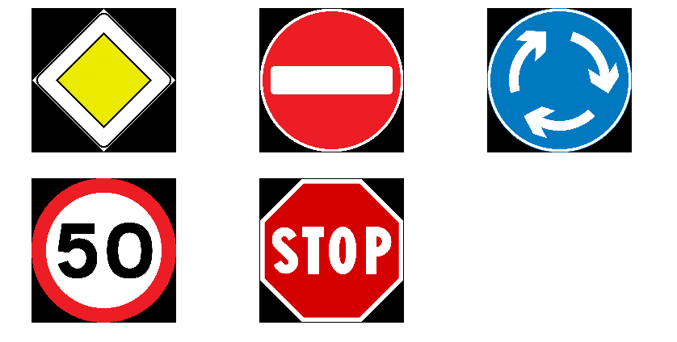

```python
############## Code Part 11: Load the new images and plot them here.

import numpy as np
import cv2
import os

new_figures = {}
new_images = []
path = "New_Images"

names = os.listdir(path)
i = 0

for name in names:
    if name.endswith('.png'):
        img = cv2.imread(path+'/'+name)
        # resize the images, shape of original image is (1024,1024,3)
        new_images.append(np.asarray(cv2.resize(img[...,::-1], (32,32))))
        # change the sequency of layers
        new_figures[i] = img[..., ::-1]
        i += 1

# function for plotting images
def plot_figures(figures, nrows = 1, ncols=1, labels=None):
    fig, axs = plt.subplots(ncols=ncols, nrows=nrows, figsize=(12, 6))
    axs = axs.ravel()
    for index, title in zip(range(len(figures)), figures):
        axs[index].imshow(figures[title], plt.gray())
        if(labels != None):
           axs[index].set_title(labels[index])

        axs[index].set_axis_off()

    plt.tight_layout()
    axs[5].set_axis_off()


# plot images of size 32x32 here.
plot_figures(new_figures, 2, 3)

# process the image files here before have them go through the model
new_images = np.asarray(new_images)
new_images = pre_process(new_images )
```

#### Performance on New Images

**Code:** `Code Part 12`

The accuracy of model prediction for new images is: 0.8

```python
############## Code Part 12: Run the predictions here and use the model to output the prediction for each image.

y_new_figures = np.array([12,17,40,2,14])

with tf.Session() as sess:
    saver.restore(sess, tf.train.latest_checkpoint('.'))
    test_accuracy = evaluate(new_images, y_new_figures)
    print("Test Accuracy = {:.3f}".format(test_accuracy))
```

```
INFO:tensorflow:Restoring parameters from ./lenet
Test Accuracy = 0.800
```

#### Model Certainty - Softmax Probabilities

**Code:** `Code Part 13` Calculate the top 5 probability.

```
INFO:tensorflow:Restoring parameters from ./lenet
```

[figure not shown]

```python
############## Code Part 13: Calculate the top 5 probability.

softmax_logits = tf.nn.softmax(logits)
top_k = tf.nn.top_k(softmax_logits, k=5)

# the function to evaluate the model after been trained.
def top5(X_data):
    sess = tf.get_default_session()
    top_k_result = sess.run(top_k, feed_dict={x: X_data, keep_prob: 1.0})
    return top_k_result

with tf.Session() as sess:
    saver.restore(sess, tf.train.latest_checkpoint('.'))
    top5res = top5(new_images)


#### Print out the top five softmax probabilities for the predictions on the German traffic sign images found on the web.
# generate a 6x5 plot.
fig, axs = plt.subplots(ncols=6, nrows=5, figsize=(20, 20))
for i in range(len(new_figures)):
    axs[i][0].imshow(new_figures[i], plt.gray())
    for j in range(1,6):
        axs[i][j].imshow(X_train0[lable_index[top5res[1][i][j-1]]])
        name = y_train[lable_index[top5res[1][i][j-1]]]
        axs[i][j].set_title(str(top5res[1][i][j-1])+' '+sign_name[name])
```

## Step 4 (Optional): Visualize the Neural Network's State with Test Images

This Section is not required to complete but acts as an additional excersise for understaning the output of a neural network's weights. While neural networks can be a great learning device they are often referred to as a black box. We can understand what the weights of a neural network look like better by plotting their feature maps. After successfully training your neural network you can see what it's feature maps look like by plotting the output of the network's weight layers in response to a test stimuli image. From these plotted feature maps, it's possible to see what characteristics of an image the network finds interesting. For a sign, maybe the inner network feature maps react with high activation to the sign's boundary outline or to the contrast in the sign's painted symbol.

For an example of what feature map outputs look like, check out NVIDIA's results in their paper [End-to-End Deep Learning for Self-Driving Cars](https://devblogs.nvidia.com/parallelforall/deep-learning-self-driving-cars/) in the section Visualization of internal CNN State. NVIDIA was able to show that their network's inner weights had high activations to road boundary lines by comparing feature maps from an image with a clear path to one without. Try experimenting with a similar test to show that your trained network's weights are looking for interesting features, whether it's looking at differences in feature maps from images with or without a sign, or even what feature maps look like in a trained network vs a completely untrained one on the same sign image.

[figure not shown]

```python
### Visualize your network's feature maps here.


# image_input: the test image being fed into the network to produce the feature maps
# tf_activation: should be a tf variable name used during your training procedure that represents the calculated state of a specific weight layer
# activation_min/max: can be used to view the activation contrast in more detail, by default matplot sets min and max to the actual min and max values of the output
# plt_num: used to plot out multiple different weight feature map sets on the same block, just extend the plt number for each new feature map entry

def outputFeatureMap(image_input, tf_activation, activation_min=-1, activation_max=-1 ,plt_num=1):
    # Here make sure to preprocess your image_input in a way your network expects
    # with size, normalization, ect if needed
    # image_input =
    # Note: x should be the same name as your network's tensorflow data placeholder variable
    # If you get an error tf_activation is not defined it may be having trouble accessing the variable from inside a function
    activation = tf_activation.eval(session=sess,feed_dict={x : image_input})
    featuremaps = activation.shape[3]
    plt.figure(plt_num, figsize=(15,15))
    for featuremap in range(featuremaps):
        plt.subplot(6,8, featuremap+1) # sets the number of feature maps to show on each row and column
        plt.title('FeatureMap ' + str(featuremap)) # displays the feature map number
        if activation_min != -1 & activation_max != -1:
            plt.imshow(activation[0,:,:, featuremap], interpolation="nearest", vmin =activation_min, vmax=activation_max, cmap="gray")
        elif activation_max != -1:
            plt.imshow(activation[0,:,:, featuremap], interpolation="nearest", vmax=activation_max, cmap="gray")
        elif activation_min !=-1:
            plt.imshow(activation[0,:,:, featuremap], interpolation="nearest", vmin=activation_min, cmap="gray")
        else:
            plt.imshow(activation[0,:,:, featuremap], interpolation="nearest", cmap="gray")
```